# R을 이용한 텍스트 파일 처리 기초 00

Ji-Myoung Choi

2023-02

## 전체 강의의 목표 및 내용

- 정제되고 효율적인 코드를 짜는 것이 목표가 아니라 반복적이고 절차적인 코드를 이용하여 코드를 이해하면서 활용하는 것이 목표이다. 따라서 기본적인 내장 함수와 꼭 필요한 외부 라이브러리만을 사용한다.
- 자료의 가공을 쉽게 사용할 수 있는 상용 도구들이 있을 경우 그 도구들을 우선 사용하는 것이 좋으며, 기존의 도구들로 처리하기 힘든 부분만 프로그래밍 언어를 도입하는 것이 좋다.

#### 강의의 목표

- 디지털 텍스트를 얻는 방법을 익힌다.
  - 이미 만들어진 텍스트 데이터를 얻거나 (web archive: e.g. Gutenberg project, Internet Archive)
  - 직접 웹 데이터를 얻어 텍스트로 가공한다 (web scraping)
- 디지털화된 텍스트 파일을 R 프로그래밍 언어로 처리하는 과정을 단계별로 익힌다.
- 처리한 결과물을 Gephi, Antconc, 엑셀 등의 도구로 사용할 수 있다.

#### 강의 대상자

- R을 이용한 디지털 인문학 연구에 관심이 있는 인문학 전공자
- 프로그래밍 배경이 전혀 혹은 거의 없는 인문학 전공자

#### 전체 강의의 내용

- R로 텍스트 파일 읽고 쓰기
- 텍스트 파일 내용 변환하기(정규식 활용)
- 웹 데이터 수집 후 처리하기
- 특수 형태 파일 포맷 처리하기: html, json, xml
- 텍스트 파일에서 정보 추출하기
  - 단어 목록
  - 문서/문장 벡터
  - 네트워크
  - co-occurrence, collocation

#### 1. 필요 도구

- R
- Rstudio / Google colab
- notepad++
- AntConc
- Excel
- 텍스트 파일(Gutenberg Project)

##### 도구 다운로드 및 설치

- R: 주 실습 도구(프로그래밍 언어)
  - R 다운로드 페이지(https://cran.r-project.org/)에서 각자의 컴퓨터 환경에 맞는 버전을 다운로드한 후 설치

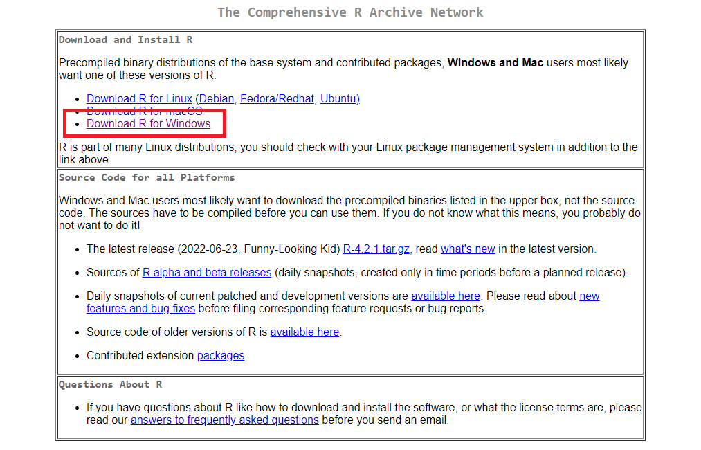

- RStudio: R 프로그래밍을 도와주는 IDE (통합개발환경)
  - 다운로드 페이지(https://posit.co/download/rstudio-desktop/)에 가서 컴퓨터 환경에 맞는 installer 버전을 다운로드한 후 설치

[figure not shown]

- Excel: 기초 통계(빈도 목록 관리 등) 및 시각화 도구(그래프)로 사용
- 텍스트 에디터(notepad++): 윈도우 메모장의 고급 버전
  - 다운로드 페이지(https://notepad-plus-plus.org/downloads/)에서 최신 버전을 다운로드 후 설치
  - 다른 텍스트 에디터를 사용 중인 경우 그 에디터를 사용해도 무방함

[figure not shown]

[figure not shown]

#### 2. R language의 특징

1. python이나 java 보다 프로그래밍 경험이 없는 연구자가 접근하기 상대적으로 용이하다.
- 파일의 입출력이나 vectorization 특성을 이용한 처리 등에서 장점이 있다.
- 딥러닝 등을 위해 python, julia 등의 언어가 필요할 경우 R 언어에 대한 이해를 바탕으로 보다 쉽게 접근 가능하다.
2. 디지털인문학 분야에서 python과 함께 가장 선호되는 언어이다.
3. Rstudio 라는 뛰어난 IDE를 사용할 수 있다.
4. Python에 비해 버전별 상호 호환성이 뛰어나다.
- 하위 버전의 R과 상위 버전의 R의 상호 호환성이 뛰어나 하위 버전의 스크립트도 상위 버전에서 별 문제 없이 작동한다.
- R로 저장한 데이터(RDS, RData)를 열 때 버전별 호환성이 뛰어나다.

##### Warning-up: R과 python의 기본 구문 비교

###### <예1> R로 파일 열기

```r
filepath <- "data/실습파일/실습파일_000.txt"
document <- readLines(filepath)
print(document)
```

```
## [1] "오케스트라 연주회장 출입이 잦아지면 차츰 무대 위 악기들에 눈이 가기 시작한다. 쉴 새 없이 움직이는 바이올린, 첼로 등 현악기부터 부드럽고 우아한 소리를 내는 목관악기, 황금빛으로 번쩍이는 금관악기와 가슴을 울리는 타악기까지…. 각각의 악기가 내는 소리를 집중해서 들어보고, 다른 악기와 어떻게 조화를 이루는지 감상하는 재미가 쏠쏠하다."
## [2] "가장 흔한 배치는 객석에서 무대를 바라볼 때를 기준으로 왼쪽부터 ‘제1바이올린-제2바이올린-비올라-첼로’ 순으로 앉히는 방식이다. 고음을 왼쪽에, 저음을 오른쪽에 배치하는 구조다. 제1바이올린과 제2바이올린이 나란히 앉아 있기 때문에 바이올린 그룹이 내는 고음을 한군데에 모아 화려한 선율을 강조할 수 있다. 미국의 전설적인 지휘자 레너드 번스타인이 선호해 ‘미국식 배치’로도 불린다."
## [3] "--- [한경닷컴 2022.07.11]"
```

1. 1행: 텍스트 파일의 위치 정보를 *filepath* 변수에 할당한다.
2. 2행: 텍스트 파일을 여는 **readLines()** 함수로 해당 위치의 텍스트 파일을 읽어 *document* 변수에 저장한다.
3. 3행: *document* 변수 내용을 출력한다.

###### <예1> Python으로 파일 열기

```python
filepath = 'data/실습파일/실습파일_000.txt'
file = open(filepath, mode='r')
document = file.read().splitlines()
file.close()
print(document)
```

```
## ['오케스트라 연주회장 출입이 잦아지면 차츰 무대 위 악기들에 눈이 가기 시작한다. 쉴 새 없이 움직이는 바이올린, 첼로 등 현악기부터 부드럽고 우아한 소리를 내는 목관악기, 황금빛으로 번쩍이는 금관악기와 가슴을 울리는 타악기까지…. 각각의 악기가 내는 소리를 집중해서 들어보고, 다른 악기와 어떻게 조화를 이루는지 감상하는 재미가 쏠쏠하다.', '가장 흔한 배치는 객석에서 무대를 바라볼 때를 기준으로 왼쪽부터 ‘제1바이올린-제2바이올린-비올라-첼로’ 순으로 앉히는 방식이다. 고음을 왼쪽에, 저음을 오른쪽에 배치하는 구조다. 제…
```

1. 1행: 텍스트 파일의 위치 정보를 *filepath* 변수에 할당한다.
2. 2행: **open()** 함수로 파일을 열고 파일 객체를 반환한다.
3. 3행: **read()** 함수로 파일을 읽어들이고 **splitlines()**로 개별 행을 분리한 후 *document* 변수에 할당한다.
4. 4행: **close()** 함수로 열어두었던 파일을 닫는다.
5. 5행: *document* 변수 내용을 출력한다.

###### <예2> R로 숫자 그룹 연산하기

```r
vec <- c(1, 3, 5)
vec_1 <- vec * 2
print(vec_1)
```

```
## [1]  2  6 10
```

1. 1행: 변수 *vec*을 생성 후 숫자값 1, 3, 5를 벡터 변수 *vec*에 할당한다.
2. 2행: *vec*에 할당된 숫자들에 2를 곱한 후 *vec_1* 변수에 할당한다.
3. 3행: *vec_1* 변수 내용을 출력한다. *vec* 변수에 저장된 개별 숫자에 각각 2을 곱한 값이 출력된다.

###### <예2> Python으로 숫자 그룹 연산하기

```python
arr = [1, 3, 5]
arr_1 = []
for a in arr:
  a_ = a * 2
  arr_1.append(a_)
print(arr_1)
```

```
## [2, 6, 10]
```

1. 1행: 변수 *arr*을 생성 후 숫자 1, 3, 5를 리스트 변수 *arr*에 할당한다.
2. 2행: 계산한 값들을 저장할 *arr_1*이라는 변수를 생성한다.
3. 3-5행: 반복문(**for-loop**)을 이용하여 *arr*의 각 요소를 하나씩 꺼내어 그 요소에 2를 곱한 후 순차적으로 *arr_1* 변수에 저장한다.
4. 6행: 변수 *arr_1*를 출력한다. *arr* 변수에 저장된 개별 숫자에 각각 2을 곱한 값이 출력된다.

###### <예2_1> Python으로 숫자 그룹 연산하기

```python
arr = [1, 3, 5]
arr_1 = arr * 3
print(arr_1)
```

```
## [1, 3, 5, 1, 3, 5, 1, 3, 5]
```

1. 1행: 변수 *arr*을 생성 후 숫자 1, 3, 5를 리스트 변수 *arr*에 할당한다.
2. 2행: R에서와 같은 식으로 변수 *arr*에 3을 곱하여 *arr_1* 변수에 할당한다.
3. 3행: *arr_1* 변수 내용을 출력한다. *vec* 변수에 저장된 개별 숫자에 각각 2을 곱한 값이 출력되지 않고 [1, 3, 5] 집합을 세 번 반복한 값이 출력된다.

###### <예3> R의 숫자 그룹 연산

```r
x <- 1:3
y <- 4:6
x_y = x + y
print(x_y)
```

```
## [1] 5 7 9
```

1. 1행: *x*라는 변수를 생성 후 1:3, 즉 1부터 3까지 세 개의 숫자를 할당한다.
2. 2행: *y*라는 변수를 생성 후 4:6, 즉 4부터 6까지 세 개의 숫자를 할당한다.
3. 3행: *x*의 각 요소와 *y*의 각 요소를 요소별로 각각 더한 후 *x_y* 변수에 할당한다.
4. 4행: *x_y*의 내용을 출력한다.

###### <예3> Python의 숫자 그룹 연산

```python
x = [1, 2, 3]
y = [4, 5, 6]
x_y = [x[i] + y[i] for i in range(len(x))]
print(x_y)
```

```
## [5, 7, 9]
```

- 위 R과 동일한 연산을 하기 위해 for-loop 즉 **for … in …** 반복문을 사용하여 요소별로 더하는 과정을 거친다.

R의 내장 함수 대부분은 한번에 각 요소에 대해 연산을 수행하도록 **for** 문을 사용하지 않고 벡터 내의 각 요소에 대해 연산 작업을 수행한다. 이러한 특성을 ‘벡터화(vectorisation)’라고 한다. python처럼 **for** 문을 사용해도 무방하나 속도와 효울성 면에서 ’벡터화’ 특성을 적극 이용하는 것이 좋다.

#### 3. R 시작하기

R을 시작하기 위해서는 1. 윈도우 시작 메뉴 R 폴더를 찾아 R 메뉴를 클릭하거나, 1. Rstudio을 시작하는 (추천 방법)

두 가지 방법이 있으나 본 강의에서는 Rstudio를 사용할 것이므로 두 번째 방법으로 R을 시작한다.

[figure not shown]

- 왼쪽 하단은 콘솔 패널(명령을 입력하고 결과를 출력하는 창) - 주로 사용할 패널 - 왼쪽 상단은 에디터 패널(R 스크립트를 작성, 편집, 저장) - 주로 사용할 패널 - 오른쪽 상단은 각종 변수 및 환경 정보 패널 - 오른쪽 하단은 설치 라이브러리, 뷰어 등 유틸리티 패널

Rstudio의 환경 패널 Rstudio의 오른쪽 상단 환경 정보 패널에 지금까지 설정한 변수들가 변수들의 값이 나타나 있다.

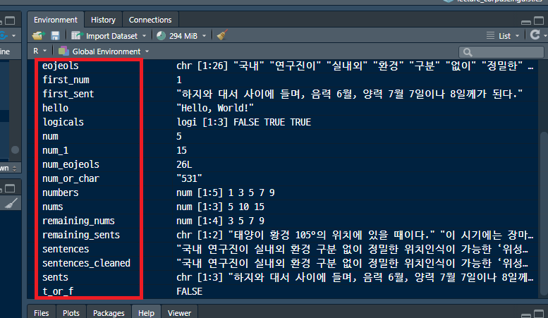

이 변수들과 할당한 값들을 모두 삭제하고자 할 때에는 다음과 같은 명령을 준다.

```r
rm(list = ls())
```

왼쪽 하단 콘솔창을 깨끗히 하는 명령은 키보드 조합 *ctrl+l*이다.

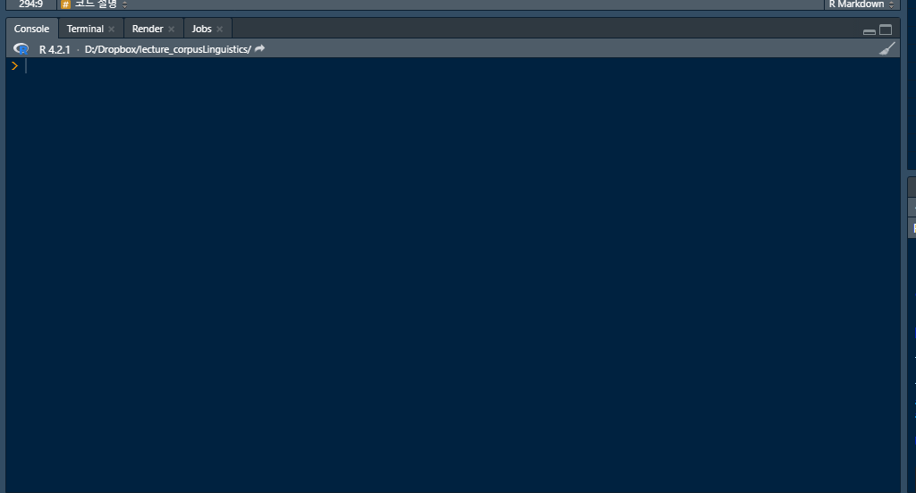

#### 4. R의 기본 구문 살펴보기

콘솔창에 R 명령어를 입력하는 방법은 다음과 같다.

한 줄씩 콘솔창에 입력하여 처리하거나

```r
hello <- "Hello, World!"
```

```r
print(hello)
```

```
## [1] "Hello, World!"
```

에디터 패널에 두 줄 이상을 입력하여 스크립트를 간단히 짠 후에 한번에 실행을 한다.

```r
hello <- "Hello, World!"
print(hello)
```

```
## [1] "Hello, World!"
```

R 프로그래밍은 기본적으로 (*이는 파이썬을 비롯한 다른 언어도 동일하다.*)

1. 변수를 지정하고,
2. 변수에 값을 넣고 (할당, assignment),
3. 값이 채워진 변수를 다른 명령어로 조작하는

세 단계로 이루어진다.  
이 최소 블록을 쌓아올리면 하나의 프로그램이 만들어진다.

위 예시에서는  
1. 1행: 첫 번째 명령에서 *hello*를 변수(혹은 변수 이름)로 지정하였고, 그 변수에 “Hello, World!”라는 문자열(string 혹은 character)을 값으로 주었다.  
R에서는 변수에 값을 할당할 때 <- 를 사용하는 것이 일반적이다.  
다른 프로그래밍 언어에서처럼 = 를 사용하는 것도 가능하나 <- 를 추천한다. 1. 2행: 두 번째 줄은 값이 주어진 변수 hello를 출력하라는 명령(**print()**)이다.  
출력 결과로 변수에 할당했던 문자열인 “Hello, World!”를 보여준다.  
*변수를 지정할 때 변수 이름은 알파벳 문자와 숫자를 이용하되, 이름의 처음은 문자로 시작한다. 이 때 대소문자는 서로 다른 것으로 본다.*

이와 같은 최소 블록을 쌓아올리면 간단한 처리 스크립트를 만들 수 있다.  
문장의 어절 수를 세는 간단한 스크립트는 다음과 같이 작성할 수 있다(사용한 함수들은 이후 회차들에서 등장하는 순서대로 간단히 설명한다.)

```r
sentences <- "국내 연구진이 실내외 환경 구분 없이 정밀한 위치인식이 가능한 ‘위성위치확인시스템(GPS)’ 시스템을 개발했다. 실내지도가 제공되지 않는 건물에서 사용자가 위치한 층의 정확한 정보를 제공할 수 있는 수준이다. [동아사이언스(https://news.v.daum.net/v/20220708160023490)]"
sentences_cleaned <- gsub(pattern = "\\.", replacement = "", x = sentences)
eojeols <- unlist(strsplit(sentences_cleaned, split = " "))
num_eojeols <- length(eojeols)
```

모든 코드가 <변수 <- 변수값>, <변수 <- 명령>의 형태로 구성되어 있다.

1. 1행: *sentences*라는 변수에 “국내 연구진이 실내외 환경 구분 없이 정밀한 위치인식이 가능한 ‘위성위치확인시스템(GPS)’ 시스템을 개발했다. 실내지도가 제공되지 않는 건물에서 사용자가 위치한 층의 정확한 정보를 제공할 수 있는 수준이다.”라는 문자열을 값으로 입력하고,
2. 2행: *sentences* 변수에 마침표(.)를 삭제하라는 명령(**gsub()**)을 한 후, 마침표가 삭제된 문장을 *sentences_cleaned*라는 새로운 변수에 할당하고
3. 3행: 새 변수에 들어있는 문자열을 공백 기준으로 구분하여 분리 후 *eojeols*라는 변수에 할당한다.
4. 4행: 마지막으로 *eojeols* 개수를 **length()** 함수를 이용하여 센 후 그 값을 *num_eojoels*에 할당한다.

최종 결과값을 출력하면 다음과 같다.

```r
print(num_eojeols)
```

```
## [1] 26
```

어절 수를 셀 때 대상이 된 어절들을 직접 보려면 *eojeols* 변수를 출력하면 된다.

```r
print(eojeols)
```

```
##  [1] "국내"
##  [2] "연구진이"
##  [3] "실내외"
##  [4] "환경"
##  [5] "구분"
##  [6] "없이"
##  [7] "정밀한"
##  [8] "위치인식이"
##  [9] "가능한"
## [10] "‘위성위치확인시스템(GPS)’"
## [11] "시스템을"
## [12] "개발했다"
## [13] "실내지도가"
## [14] "제공되지"
## [15] "않는"
## [16] "건물에서"
## [17] "사용자가"
## [18] "위치한"
## [19] "층의"
## [20] "정확한"
## [21] "정보를"
## [22] "제공할"
## [23] "수"
## [24] "있는"
## [25] "수준이다"
## [26] "[동아사이언스(https://newsvdaumnet/v/20220708160023490)]"
```

```r
sentences <- "In the population of Transylvania there are four distinct nationalities: Saxons in the South, and mixed with them the Wallachs, who are the descendants of the Dacians; Magyars in the West, and Szekelys in the East and North."
sentences_cleaned <- gsub(pattern = "\\.", replacement = "", x = sentences)
eojeols <- unlist(strsplit(sentences_cleaned, split = " "))
print(eojeols)
```

```
##  [1] "In"             "the"            "population"     "of"
##  [5] "Transylvania"   "there"          "are"            "four"
##  [9] "distinct"       "nationalities:" "Saxons"         "in"
## [13] "the"            "South,"         "and"            "mixed"
## [17] "with"           "them"           "the"            "Wallachs,"
## [21] "who"            "are"            "the"            "descendants"
## [25] "of"             "the"            "Dacians;"       "Magyars"
## [29] "in"             "the"            "West,"          "and"
## [33] "Szekelys"       "in"             "the"            "East"
## [37] "and"            "North"
```

#### 5. R을 이용한 텍스트 처리에서 자주 사용할 데이터 유형

- https://seong6496.tistory.com/265
1. 문자열(character): 단어, 문장, 문서 등 문자로 된 유형. 문자를 다룰 수 있는 다양한 추가, 삽입, 수정, 삭제 기능을 제공함(길이 구하기, 인덱싱, 슬라이싱, 갯수 세기, 위치 찾기, 삽입, 대체하기, 나누기 등..).
2. 벡터(vector): 1개 이상의 요소를 가진 1차원의 데이터 구조. 요소(들)을 1차원의 공간에 배치하는 데이터 구조. 2개 이상의 요소를 가진 벡터는 **c()** 함수(’combine)로 만들수 있다.
   - 인덱싱(indexing)과 서브셋(subsetting) 사용 가능. 수정, 삭제, 추가, 정렬, 뒤집기, 삽입 등 모두 가능
   - 한 벡터에는 한 가지 속성의 요소들만 포함: 문자형(character), 숫자형(numeric), 논리형(logical)
   - 벡터의 각 요소에는 이름(name)을 부여할 수 있다. 이름이 부여된 vector는 파이썬의 딕셔너리(dictionary: 요소는 key: value 쌍)와 유사하다.
3. 리스트(list): 하나 이상의 벡터로 이루어진 묶음. 문자, 숫자, 논리 등 여러 유형의 데이터를 포함할 수 있다. 인덱싱(indexing)과 서브셋(subsetting) 사용 가능. 수정, 삭제, 추가, 정렬, 뒤집기, 삽입 등 모두 가능
4. 데이터프레임(dataframe): 엑셀 파일과 같이 행과 열로 이루어진 데이터 유형. R의 고유한 데이터 유형으로 R의 가장 큰 장점이 발휘되는 유형.

##### 변수에 할당할 수 있는 값의 유형

변수에 할당할 수 있는 값은 문자열, 숫자, 논리값 등이다.

```r
hello <- "Hello, World!"
num <- 5
num_1 <- num + 10
t_or_f <- 5 == 10
```

1. 1행: “Hello, World!”라는 문자열(character string)을 변수 *hello*에 할당한다.
2. 2-3행: 숫자(number) 5를 변수 *num*에 할당한다.
3. 4행: 5와 10이 같다는 논리 표현(logical)을 변수 *t_or_f*에 할당한다.

각 변수의 유형은 다음과 같이 확인해 볼 수 있다.

```r
print(class(hello))
```

```
## [1] "character"
```

```r
print(class(num))
```

```
## [1] "numeric"
```

```r
print(class(num_1))
```

```
## [1] "numeric"
```

```r
print(class(t_or_f))
```

```
## [1] "logical"
```

하나 이상의 값을 변수에 할당할 수도 있다. 이 때는 **c(…)**(combine) 함수를 이용하여 두 개 이상의 값을 묶어준다.

```r
char_str <- c("Hello, World!", "Hello, friends!", "Hello, brothers!")
nums <- c(5, 10, 15)
logicals <- c(5 == 10, 10 == 10, 5*2 == 10)
```

1. 1행: “Hello, World!”, “Hello, friends!”, “Hello, brothers!” 등 3개의 문장을 *char_str*에 할당한다.
2. 2행: 숫자 5, 10, 15를 *nums*에 할당한다.
3. 3행: 논리 표현 3개를 *logicals*에 할당한다.

```r
print(char_str); print(nums); print(logicals)
```

```
## [1] "Hello, World!"    "Hello, friends!"  "Hello, brothers!"
```

```
## [1]  5 10 15
```

```
## [1] FALSE  TRUE  TRUE
```

할당된 값들의 개수를 알려면 **length()** 함수를 사용한다.

```r
print(
  length(char_str)
)
```

```
## [1] 3
```

변수에 할당된 값이 하나 이상일 경우, 할당된 값들의 일부를 범위 지정자 [ ]로 지정하여 꺼내어 쓸 수 있다(subsetting). [ ] 내에는 요소들의 위치값(index) 혹은 위치값 범위를 준다.

```r
sents <- c("하지와 대서 사이에 들며, 음력 6월, 양력 7월 7일이나 8일께가 된다.", "태양이 황경 105°의 위치에 있을 때이다.", "이 시기에는 장마전선이 우리 나라에 오래 자리잡아 습도가 높아지고, 장마철을 이루는 수가 많다. [소서. 한국민족문화 대백과사전]")
numbers <- c(1, 3, 5, 7, 9)

first_sent <- sents[1]
remaining_sents <- sents[2:3]

first_num <- numbers[1]
remaining_nums <- numbers[2:5]
```

결과는 다음과 같이 출력한다.

```r
print(first_sent); print(remaining_sents); print(first_num); print(remaining_nums)
```

```
## [1] "하지와 대서 사이에 들며, 음력 6월, 양력 7월 7일이나 8일께가 된다."
```

```
## [1] "태양이 황경 105°의 위치에 있을 때이다."
## [2] "이 시기에는 장마전선이 우리 나라에 오래 자리잡아 습도가 높아지고, 장마철을 이루는 수가 많다. [소서. 한국민족문화 대백과사전]"
```

```
## [1] 1
```

```
## [1] 3 5 7 9
```

문자열인 경우에는 반드시 인용 부호(“” 혹은 ’’)를 사용하여 다른 유형과 구분해 주어야 한다. 만약 숫자값에 인용 부호를 사용하면 그 값은 숫자가 아닌 문자로 인식된다.

```r
num_or_char <- "531"
char_or_num <- 531
```

```r
print(class(num_or_char)); print(class(char_or_num))
```

```
## [1] "character"
```

```
## [1] "numeric"
```

1. 1행: *num_or_char*는 문자열, *char_or_num*은 숫자임을 확인할 수 있다.

R을 계산기처럼 사용할 수도 있다.

```r
a <- 5
b <- 10
a_sum_b <- a + b
a_mul_b <- a * b
b_div_a <- b / a
```

```r
print(a); print(b); print(a_sum_b); print(a_mul_b); print(b_div_a)
```

```
## [1] 5
```

```
## [1] 10
```

```
## [1] 15
```

```
## [1] 50
```

```
## [1] 2
```

#### 6. 문자열 다루기

##### 문자열 입력하기

```r
string_1 <- "character"
string_2 <- "This is a character string."
string_3 <- "Dave's most favourite food is pizza."
string_4 <- 'Hello there\", she said.'
string_4_1 <- "\"Hello there\", she said."
string_5 <- c("apple", "banana", "strawberry", "사과", "바나나", "딸기")
```

1. 1-3행: 문자열 “character”와 “This is a character string.”을 *string_1*과 *string_2*에 각각 할당한다. R에서 문자열을 변수에 입력할 때에는 기본적으로 쌍따옴표(““)를 사용한다.
2. 4행: 문자열 중간에 “가 들어있을 때에는 문자열 구분 기호인 쌍따옴표와 구분하기 위해 홑따옴표(’’)를 사용한다.
3. 5행: 문자열 중간에 “가 들어있을 때에는” 기호 앞에 \ 기호를 붙이고 쌍따옴표(““)를 사용할 수 있다.
4. 6행: **c()** 함수를 이용하여 두 개 이상의 문자열 요소들을 변수에 할당할 수 있다.

```r
print(string_3)
```

```
## [1] "Dave's most favourite food is pizza."
```

1. 1행: *string_3*의 내용을 출력한다.

```r
print(string_4_1)
```

```
## [1] "\"Hello there\", she said."
```

1. 1행: *string_4_1*의 내용을 출력한다. \ 기호가 보이더라도 정상적인 현상이다.

```r
print(string_5)
```

```
## [1] "apple"      "banana"     "strawberry" "사과"       "바나나"
## [6] "딸기"
```

1. 1행: *string_5*의 내용을 출력한다. 영어와 한글 모두 문자열이므로 입력한 내용이 정상적으로 출력된다.

##### 문자열 길이 구하기

- **length()** 함수로 문자열이 몇 개의 단어로 이루어졌는지 확인할 수 있다.
- **nchar()** 함수로 문자열이 몇 개의 문자로 이루어졌는지 확인할 수 있다.

```r
str_len = length(string_1)
```

1. 1행: 변수에 저장된 요소들의 길이를 구할 때는 **length()** 명령어(즉 함수)를 이용한다.

```r
print(str_len)
```

```
## [1] 1
```

1. 1행: 변수 *str_len*의 내용을 출력한다. *string_1*은 1개의 요소로 이루어진 벡터 변수이다.

```r
char_len <- nchar(string_1)
```

```r
print(char_len)
```

```
## [1] 9
```

1. 1행: c-h-a-r-a-c-t-e-r 등 9개의 문자로 되어 있음을 알 수 있다.

```r
print(nchar(string_2))
```

```
## [1] 27
```

1. 1행: *string_2*에 저장된 문장 “This is a character string.”을 구성하는 문자들의 갯수를 세어 그 결과를 출력한다. 두 개의 함수를 연속하여 사용할 수 있다. “This is a character string.”은 총 27개의 문자로 이루어져 있다. 이 중 22개는 알파벳 문자, 4개는 공백(스페이스) 문자, 1개는 구두점(마침표) 문자이다. 공백과 구두점도 개별 문자로 취급되는 것을 알 수 있다.

##### 문자열 벡터의 인덱싱 및 서브세팅(subsetting)

```r
print(string_5[1])
```

```
## [1] "apple"
```

1. 1행: 벡터 내 요소 중 일부를 선택할 때에서는 [ ] 기호와 함께 인덱스 값을 이용한다. [1]는 첫 번째 요소를 선택한다는 의미이다.

```r
print(string_5[1:3])
```

```
## [1] "apple"      "banana"     "strawberry"
```

1. 1행: [1:3]은 첫 번째에서 세 번째까지의 요소를 선택한다는 의미이다.

```r
print(string_5[4:length(string_5)])
```

```
## [1] "사과"   "바나나" "딸기"
```

1. 1행: 벡터 변수 *string_5*에 저장된 요소들 줄 네 번째에서 마지막 번째까지의 요소를 출력한다. 벡터의 마지막 요소의 위치값은 **length()** 함수로 얻을 수 있다.

##### 문자열 중 n개 문자 얻기

- 문자열 중 첫 n개 문자 얻기 문자열에서 문자 단위로 출력할 때에는 **substr()** 함수(substring)를 이용한다. 시작 문자와 끝 문자의 위치를 함수의 항으로 제공한다.

```r
print(substr(string_3, start = 1, stop = 4))
```

```
## [1] "Dave"
```

1. 1행: *string_3*에 저장된 Dave’s most favourite food is pizza.에서 첫 번째 문자에서 4번째 문자까지인 Dave를 출력한다. 선택할 범위는 시작 글자 위치(start) 1에서 끝 글자 위치(stop) 4까지이다. 첫 번째 문자만 선택하려면 start = 1, stop = 1로 지정한다.
- 문자열 중 마지막 n개 문자 얻기

```r
str = "This is an example."
n = 8
result = substr(str, start = (nchar(str)+1)-n, stop = nchar(str))
print(result)
```

```
## [1] "example."
```

```r
print(substr(str, start = (nchar(str))-n, stop = nchar(str)))
```

```
## [1] " example."
```

##### 문자 갯수 세기

```r
# install.library(stringr)

library(stringr)
num_a <- str_count(string = string_1, pattern = "a")
print(num_a)
```

```
## [1] 2
```

1. 1행: **install.library(‘라이브러리명’)** 함수로 **stringr** 패키지를 설치한다. 이 패키지는 문자열을 다루기 위한 함수들을 많이 담고 있다.
2. 3행: **library(라이브러리명)** 함수로 설치한 **stringr** 패키지를 탑재한다. 이제부터 이 페키지에 설치된 모든 함수들을 사용할 수 있다. 이 패키지에 대한 설명은 RStudio 콘솔창에 **?stringr**를 입력하면 된다.
3. 4행: stringr 라이브러리의 **str_count()** 함수가 일차하는 문자열을 찾아 세는 기능을 한다. 이 함수의 첫 번째 항은 대상이 되는 문자열, 두 번째 항이 찾고자 하는 문자열 패턴이다. 여기서는 character라는 문자열 내에 a가 몇 번 나타났는지 세고자 한다. 그 결과를 *num_a*에 저장한다.
4. 5행: *num_a*를 출력한다.

##### 문자열 앞뒤에 새로운 문자 삽입하기

```r
new_string_1 <- paste(string_1, "_1", sep = "")
new_string_2 <- paste("new_", string_1, sep = "")
```

1. 1행: 기존 문자열 다음에 새로운 문자 “_1”을 **paste()** 함수로 연결한다. 이 때 두 문자열 사이에 아무 문자도 들어가지 않게 하기 위해 **sep** 항을 ““로 설정한다. 만약 두 문자열을”-“로 연결하고 싶으면 sep =”-“로 지정한다. 새로 만들어진 문자열을 *new_string_1*에 저장한다.
2. 2행: 기존 문자열 앞에 새로운 문자 “new_”를 **paste()** 함수로 연결한다. 새로 만들어진 문자열을 *new_string_2*에 저장한다.

```r
# print(new_string_1); print(new_string_2)
print(c(new_string_1, new_string_2))
```

```
## [1] "character_1"   "new_character"
```

1. 1행: *new_string_1*과 *new_string_2*를 출력한다. 두 개 이상의 문자열을 한번에 출력하려면 출력하고자 하는 변수를 **c()**로 묶은 후 이를 출력하면 된다.

문자열 중간 부분(세 번째와 네 번째 문자 사이)에 새로운 문자 삽입하기

```r
part_1 <- substr(string_1, 1, 3)
part_2 <- substr(string_1, 4, nchar(string_1))
new_char <- "-"
new_string_3 <- paste(part_1, part_2, sep = new_char)
print(new_string_3)
```

```
## [1] "cha-racter"
```

```r
new_string_3 <- paste(substr(string_1, 1, 3), substr(string_1, 4, nchar(string_1)), sep = "-")
print(new_string_3)
```

```
## [1] "cha-racter"
```

1. 1행: 4줄로 된 위 코드를 한 줄로 줄일 수 있다.

##### 문자열 양쪽 공백 지우기

문자열의 시작 부분과 끝 부분에 불필요한 공백이 있을 때 **trimws()** 함수를 사용하여 삭제할 수 있다. 여러 라인으로 구성된 텍스트 파일을 읽어 각 라인의 앞뒤 공백을 지우고자 할 때 사용한다.

```r
string_6 = '    character    '
string_6_1 = trimws(string_6)
print(string_6_1)
```

```
## [1] "character"
```

1. 1행: 문자열 앞뒤로 공백이 여러 개 들어간 문자열 ’ character ’를 *string_6*에 저장한다.
2. 2행: **trimws()** 함수로 *string_6*의 앞뒤 공백을 제거한 후 *string_6_1*에 저장한다.
3. 3행: *string_6_1*을 출력한다. 앞뒤 공백이 삭제된 깔끔한 문자열을 확인할 수 있다.

##### 대소문자로 바꾸기

```r
upper_string_1 = toupper(string_1)
print(upper_string_1)
```

```
## [1] "CHARACTER"
```

```r
print(tolower(upper_string_1))
```

```
## [1] "character"
```

##### 문자열 바꾸기

**sub()** 함수로 문자열 내의 특정 문자를 다른 것으로 교체할 수 있다.

```r
print(sub(pattern = 'pizza', replacement = 'hamburger', x = string_3))
```

```
## [1] "Dave's most favourite food is hamburger."
```

1. 1행: *string_3*에 저장된 Dave’s most favourite food is pizza.에서 ’pizza’를 ’hamburger’로 바꾼다. **sub()** 함수의 괄호 내 첫 번째 항에는 바꾸고자 하는 기존 문자열을, 두 번째 항에는 새 문자열을, 세 번째 항에는 대상이 되는 문자열을 기입한다.

```r
print(sub(pattern = 'Dave', replacement = 'Jane', string_3))
```

```
## [1] "Jane's most favourite food is pizza."
```

1. 1행: *string_3*에 저장된 문자열에서 Dave를 Jane으로 바꾼 후 출력한다.

##### 문자열 나누기(분할하기)

```r
splitted_string_3 = strsplit(string_3, split = " ")
print(splitted_string_3)
```

```
## [[1]]
## [1] "Dave's"    "most"      "favourite" "food"      "is"        "pizza."
```

1. 1행: **strsplit()** 함수를 사용한다. 나누고자 하는 문자열을 이 함수의 첫 번째 항에, 분할 기준을 두 번째 항인 **split**에 지정한다. 여기서는 띄어쓰기 공백을 기준으로 원래 문자열을 분할한다. *string_3*에 저장된 문장을 공백 기준으로 잘라서 *splitted_string_3*에 저장한다.
2. 2행: *splitted_string_3*을 출력한다. 기존 문장이 6개 단어로 분할되었다. **strsplit()**은 분할 결과를 리스트로 반환한다.

```r
splitted_string_3_1 = unlist(strsplit(string_3, split = " "))
print(splitted_string_3_1)
```

```
## [1] "Dave's"    "most"      "favourite" "food"      "is"        "pizza."
```

1. 1행: **strsplit()** 함수를 사용한다. 나누고자 하는 문자열을 이 함수의 첫 번째 항에, 분할 기준을 두 번째 항인 **split**에 지정한다. 여기서는 띄어쓰기 공백을 기준으로 원래 문자열을 분할한다. **strsplit()**를 둘러싸는 또 다른 함수 **unlist()**를 이용하여 리스트형을 벡터로 변환한다.
2. 2행: *splitted_string_3_1*을 출력한다. 기존 문장이 6개 단어로 분할되었다. *splitted_string_3*과 *splitted_string_3_1*의 차이는 전자가 리스트 유형, 후자가 벡터 유형이라는 것이다.

```r
print(c(class(splitted_string_3), class(splitted_string_3_1), is.vector(splitted_string_3_1)))
```

```
## [1] "list"      "character" "TRUE"
```

1. 1행: 변수 *splitted_string_3*, *splitted_string_3_1*의 데이터 유형을 확인해 보기 위해 **class()** 함수를 사용한다. 데이터 유형이 리스트임을 알 수 있다. 마지막으로 *splitted_string_3_1*가 벡터 유형이 맞는지 다시 확인하기 위해 **is.vector()** 함수를 사용하였다. 그 결과 TRUE를 반환한다. 리스트가 맞는지 확인하는 함수는 **is.list()**이다.

```r
string_7 = 'character, letter, number'
print(unlist(strsplit(string_7, split = ", ")))
```

```
## [1] "character" "letter"    "number"
```

1. 1행: 세 개의 단어가 쉼표로 구분되어 있는 문자열을 입력하여 *string_7*에 저장한다.
2. 2행: *string_7*을 분할하되 분할 기준을 쉼표와 공백, 즉 ’, ’로 설정한다. 이렇게 분할된 *string_7*을 출력한다. 세 개의 단어로 잘 구분된 것을 볼 수 있다.

#### 7. 벡터(vector) 다루기

벡터는 하나 이상의 요소(element)를 가지는 집합과 유사한 개념 - 인덱싱과 서브세팅(subsetting)을 통해 일부 요소의 추출 가능

##### 벡터 만들기

벡터는 **c()** 함수를 사용하여 만들 수 있다. 여기에 문자, 숫자, 리스트 등이 구성 요소로 들어갈 수 있다.

```r
vec_1 <- c(1, 2, 3, 4, 5)
vec_1_1 <- c(5, 4, 3, 2, 1)
vec_2 <- c('apple', 'banana', 'orange', 'pineapple', 'watermelon')
print(vec_2)
```

```
## [1] "apple"      "banana"     "orange"     "pineapple"  "watermelon"
```

1. 1행: 숫자 1에서 5까지를 벡터(c(…))로 만들어 *vec_1*에 저장한다.
2. 2행: 숫자 5에서 1까지를 벡터(c(…))로 만들어 *vec_1_1*에 저장한다.
3. 3행: 과일 이름 단어(문자열) 5개를 벡터(c(…))로 만들어 *vec_2*에 저장한다.
4. 4행: 벡터 변수 *vec_2*를 출력한다. 5개 단어가 들어있는 벡터이다.

```r
vec_3 = c()
vec_3 <- c(vec_3, 9)
vec_3 <- c(vec_3, 10)
print(vec_3)
```

```
## [1]  9 10
```

1. 1행: 빈 벡터를 만들어 *vec_3*에 할당한다. 요소가 들어있지 않은 빈 벡터는 c()로 간단히 만들 수 있다. 이 벡터에는 새로운 값들을 추가할 수 있다.
2. 2행: *vec_3*에 숫자 9를 추가한다. 벡터에 요소를 추가할 때는 **c(기존 벡터, 새로운 값)**과 같은 식으로 추가한다. 즉 1행에서 만든 기존 벡터에 새로운 값 9를 추가한다.
3. 3행: 이 *vec_3*에 숫자 10을 다시 추가한다.
4. 4행: *vec_3*을 출력한다. 새로 추가한 숫자 9와 10이 들어있다.

```r
vec_3_1 <- vec_3[-1]
print(vec_3_1)
```

```
## [1] 10
```

1. 1행: 리스트의 요소를 삭제할 때는 […]와 함께 인덱스 값을 이용한다. vector[-1]은 vector에서 첫 번째 요소를 삭제하라는 의미이다. 여기서는 9와 10이 저장된 *vec_3*에서 첫 번째 요소를 삭제한 후 새 변수 *vec_3_1*에 저장하라는 의미이다.
2. 2행: *vec_3_1*을 출력한다. 10만 남아있다.

##### 리스트 인덱싱 및 슬라이싱(slicing)하기

```r
print(vec_1[1])
```

```
## [1] 1
```

1. 1행: 인덱스를 이용하여 *vec_1*에서 첫 번째 요소를 선택 후 출력한다. 위에서 문자열의 인덱싱과 동일하다.

```r
print(vec_1[1:3])
```

```
## [1] 1 2 3
```

```r
print(vec_2[2:3]); print(vec_2[c(2, 3)])
```

```
## [1] "banana" "orange"
```

```
## [1] "banana" "orange"
```

1. 1행: *vec_2*에서 두 번째에서 세 번째까지의 요소를 출력한다. [2:3]은 [c(2, 3)]과 같다. 즉 두 번째와 세 번째 요소를 가리킨다.

##### 리스트 정렬하기

```r
sorted_vec_1_1 <- sort(vec_1_1)
print(sorted_vec_1_1)
```

```
## [1] 1 2 3 4 5
```

1. 1행: 숫자 5에서 1까지 요소가 들어있는 *vec_1_1*을 **sort()** 함수로 정렬한 후 *sorted_vec_1_1*에 저장한다.
2. 2행: 정렬된 *sorted_vec_1_1*을 출력한다. 원래 내림차순이었던 리스트가 오름차순 리스트로 바뀌었다.

```r
sorted_vec_2 <- sort(vec_2, decreasing = T)
print(sorted_vec_2)
```

```
## [1] "watermelon" "pineapple"  "orange"     "banana"     "apple"
```

1. 1행: 알파벳 오름차순으로 되어 있던 *vec_2*를 **sort(., decreasing = T)**를 이용하여 내림차순으로 정렬한다. 내림차순으로 정렬할 때는 **sort()** 함수에서 **decreasing = T** 항을 추가한다.
2. 2행: 내림차순 정렬된 *sorted_vec_2*를 출력한다.

##### 리스트 요소 갯수 세기

```r
print(length(vec_1))
```

```
## [1] 5
```

1. 1행: 리스트에 들어있는 요소들의 수를 셀 때는 **length()** 함수를 이용한다.

```r
vec_4 = c("a", "b", "c", "a", "d", "e", "a")
print(length(which(vec_4 == "a")))
```

```
## [1] 3
```

1. 1행: 알파벳 문자 7개로 된 벡터를 만들어 *vec_4*에 저장한다.
2. 2행: *vec_4*에 들어있는 알파벳 ’a’의 갯수를 세기 위해 **which()** 함수를 이용한다. **which()**는 벡터에서 원하는 값이 어디에 위치하고 있는지 구할 때 사용한다. 즉 *vec_4*의 어떤 것(which)이 ’a’인지를 묻는 함수이다. 문자 외에 숫자, 논리값 등을 모두 찾을 수 있다. **which()** 함수는 위치값, 즉 인데스 값을 반환한다. 이 인덱스의 갯수를 세면 ’a’가 몇 개 들어있는지 알 수 있다.

```r
print(which(vec_1 > 1))
```

```
## [1] 2 3 4 5
```

```r
print(which(vec_1 > 1 & vec_1 < 5))
```

```
## [1] 2 3 4
```

1. 1행: 숫자 [1, 2, 3, 4, 5]가 들어있는 벡터에서 1을 초과하는 값의 위치를 반환한다.
2. 2행: 숫자 [1, 2, 3, 4, 5]가 들어있는 벡터에서 1을 초과하고 (and 조건: &) 5 미만인 값의 위치를 반환한다.

#### 8. 네임드 벡터(named vector) 만들기

- named vector는 벡터의 각 요소에 이름(name)을 부여한 것이다. 이름을 통해 그 이름에 해당하는 값을 찾을 수 있다. - **names(vector)** 함수로 만든다.

```r
named_vec_1 = c(10, 4, 7, 2, 1)
names(named_vec_1) <- c("apple", "banana", "orange", "pineapple", "watermelon")
print(named_vec_1)
```

```
##      apple     banana     orange  pineapple watermelon
##         10          4          7          2          1
```

1. 1행: *named_vec_1*에 먼저 값(value), 예를 들어 과일들의 갯수를 벡터로 입력한다.
2. 2행: **names()** 함수로 *named_vec_1*에 과일 이름을 추가한다. 이 때 과일의 이름도 벡터 형식으로 만든다.
3. 3행: *named_vec_1*를 출력한다. 값과 함께 이름이 같이 출력된다.

##### 네임드 벡터(named vector) 내용 들여다보기: name 값을 이용하여 값을 확인

```r
print(named_vec_1[which(names(named_vec_1) == "apple")])
```

```
## apple
##    10
```

1. 1행: *named_vec_1*에 저장된 요소들의 이름 중에 “apple”헤 해당하는 것의 위치를 **which()** 함수로 확인한다. 벡터의 인덱싱 기능을 이용하여 이 값을 인덱스로 하여 *named_vec_1*에서 원하는 요소를 추출한다. apple의 갯수는 10개이다.

##### 네임드 벡터(named vector)에서 이름과 값을 따로 추출하기

```r
list_names = names(named_vec_1)
print(list_names)
```

```
## [1] "apple"      "banana"     "orange"     "pineapple"  "watermelon"
```

1. 1행: **names()** 함수로 *named_vec_1*에서 이름만 추출하여 *list_names*에 저장한다. 저장된 값은 벡터이다.
2. 2행: 벡터 *list_names*를 출력한다.

```r
list_values = unname(named_vec_1)
print(list_values)
```

```
## [1] 10  4  7  2  1
```

1. 1행: **unname()** 함수로 *named_vec_1*에서 이름을 제외하고 값만 추출하여 *list_values*에 저장한다. 저장된 값은 벡터이다.
2. 2행: 벡터 *list_values*를 출력한다.

#### 9. 주로 많이 사용하는 기본 함수의 종류

**nchar()**: 입력한 문장이나 단어의 문자 수를 센다(공백 포함).

```r
single_wrd <- "할당하다"
single_chars <- nchar(single_wrd)

two_wrds <- c("할당하다", "문자")
two_chars <- nchar(two_wrds)

print(single_chars); print(two_chars)
```

```
## [1] 4
```

```
## [1] 4 2
```

- 라인 1: *single_wrd*라는 변수에 “할당하다”하는 단어 하나를 할당한다.
- 라인 2: **nchar()** 함수로 *single_wrd*에 저장된 단어의 글자 수를 센 후 그 값을 변수 *single_chars*에 할당한다.
- 라인 3: *two_wrds*라는 변수에 “할당하다”, “문자”라는 두 개의 단어를 할당한다. 두 개 이상의 값을 한 변수에 할당할 때는 **c()** 함수로 묶어준다.
- 라인 4: *two_wrds*에 할당된 두 개 단어의 글자 수를 각각 센 후 *two_chars* 변수에 할당한다.
- 라인 5: 두 변수 *single_chars*와 *two_chars*를 각각 출력한다.

**readLines()**: 텍스트 파일을 읽는다.  
**writeLines()**: 변수의 내용을 텍스트 파일로 저장한다.  
**strsplit()**: 문자열을 구분자를 이용하여 작은 단위로 분리한다. (예: 단어, 문장 등)  
**unlist()**: 이중 구조인 리스트 데이터를 단일 구조로 변환한다.  
**table()**: 빈도 정보를 구한다.  
**grep()**: 특정 문자열을 찾아 위치를 반환한다.  
**gsub()**: 문자열을 찾은 후 원하는 다른 문자열로 바꾼다.  
**print()**: 변수에 저장된 내용을 출력한다.  
**for** 문: 주어진 횟수만큼 동일 작업을 반복한다.